R语言大作业 金小龙 吴大宇 车联网数据分析

# Data1 Analysis

Wu Dayu(PB19030934) and Jin Xiaolong(PB19000314)

Project background: Internet of Vehicles data, In simple terms, the data is vehicle-related data recorded by on-board equipment: including real-time driving speed, acceleration, fuel consumption, engine speed, etc. Through the statistical analysis of Internet of Vehicles data, it can bring certain value to insurance companies, car manufacturers and driving drivers. The data provides Internet of Vehicles data for a trival of a car.The data includes time(TIME), longitude(LONG) ,latitude(LAT) ,fuel consumption (CONSUM),acceleration(LONGACC) ,speed(SPEED) ,engine speed(WHEEL) ,cumulative distance.

## Descriptive Statistics and Analysis

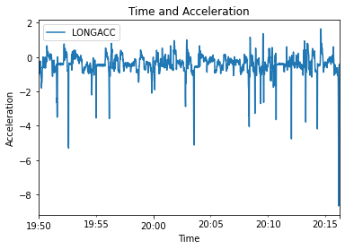

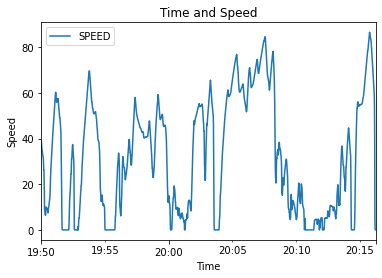

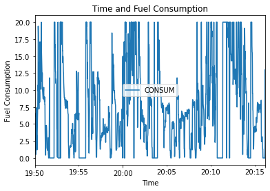

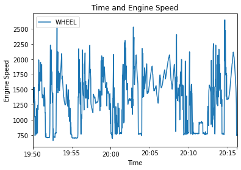

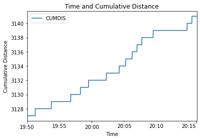

```python
# import package
import pandas as pd
import numpy as np
import matplotlib.pyplot as plt

# load data
df1 = pd.read_csv("data1.csv")
num = len(df1)

# time
df1["TIME_1s"]=pd.date_range(start='2016-11-11 19:50', periods=num,freq="S")
df1.set_index("TIME_1s")

# observe the trend of data over time


df1.plot(x="TIME_1s",y="LONGACC",title='Time and Acceleration',xlabel="Time",ylabel="Acceleration")

df1.plot(x="TIME_1s",y="SPEED",title='Time and Speed',xlabel="Time",ylabel="Speed")

df1.plot(x="TIME_1s",y="CONSUM",title='Time and Fuel Consumption',xlabel="Time",ylabel="Fuel Consumption")

df1.plot(x="TIME_1s",y="WHEEL",title='Time and Engine Speed',xlabel="Time",ylabel="Engine Speed")

df1.plot(x="TIME_1s",y="CUMDIS",title='Time and Cumulative Distance',xlabel="Time",ylabel="Cumulative Distance")
```

```python
df1.describe()
```

|  | LONG | LAT | CONSUM | LONGACC | SPEED | WHEEL | CUMDIS |
| --- | --- | --- | --- | --- | --- | --- | --- |
| count | 1575.000000 | 1575.000000 | 1575.00000 | 1575.000000 | 1575.000000 | 1575.000000 | 1575.000000 |
| mean | 122.097300 | 40.187616 | 7.56381 | -0.422438 | 32.740143 | 1354.246667 | 3133.685714 |
| std | 0.019677 | 0.018116 | 6.34133 | 0.631214 | 24.969690 | 421.837816 | 4.390372 |
| min | 122.071075 | 40.164811 | 0.00000 | -8.660000 | 0.000000 | 657.500000 | 3127.000000 |
| 25% | 122.081715 | 40.167381 | 2.40000 | -0.620000 | 8.925000 | 947.500000 | 3129.000000 |
| 50% | 122.087852 | 40.190479 | 6.40000 | -0.420000 | 32.175000 | 1401.500000 | 3133.000000 |
| 75% | 122.121736 | 40.205306 | 11.30000 | -0.140000 | 54.375000 | 1669.375000 | 3139.000000 |
| max | 122.127008 | 40.212045 | 20.00000 | 1.640000 | 86.625000 | 2650.000000 | 3141.000000 |

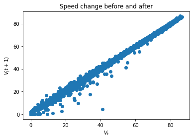

```python
# 前后时刻的速度

# V_t+1
speed_1 =  df1["SPEED"][1:num]

# Speed change before and after
plt.scatter(df1["SPEED"][0:(num-1)],speed_1)
plt.xlabel("$V_t$")
plt.ylabel("$V_(t+1)$")
plt.title("Speed change before and after")
```

Plot the speed scatter plot before and after the measurement time, we can analyze the driving stability of the car owner.If the speed difference between the front and the rear is too large and it is not on the overall regression line, it means that the speed of the car is changing drastically at this time.

If there are too many outliers, it means that the driver's driving habits are not good, and they often stop and speed up quickly, which is dangerous. Therefore, the price of insurance for the driver should be increased.

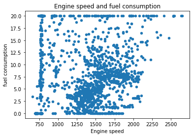

```python
#Engine speed and fuel consumption
df1.plot.scatter(x="WHEEL",y="CONSUM",title='Engine speed and fuel consumption')
plt.xlabel("Engine speed")
plt.ylabel("fuel consumption")
```

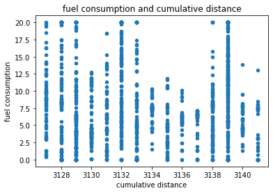

```python
# fuel consumption and cumulative distance
df1.plot.scatter(x="CUMDIS",y="CONSUM",title='fuel consumption and cumulative distance')
plt.xlabel("cumulative distance")
plt.ylabel("fuel consumption")
```

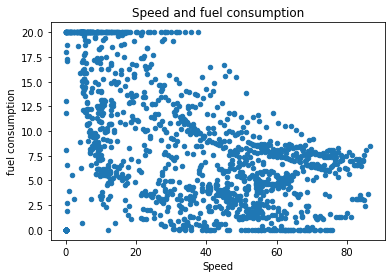

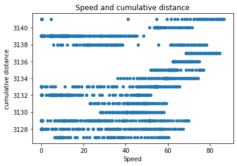

```python
# speed and fuel consumption
df1.plot.scatter(x="SPEED",y="CONSUM",title='Speed and fuel consumption')
plt.xlabel("Speed")
plt.ylabel("fuel consumption")


# Speed and cumulative distance
df1.plot.scatter(x="SPEED",y="CUMDIS",title='Speed and cumulative distance')
plt.xlabel("Speed")
plt.ylabel("cumulative distance")
```

As can be seen from the above two graphs, speed and fuel consumption are negatively correlated.When the speed increases, fuel consumption tends to decrease.Besides this,from graph2,we know that when the accumulated distance is larger, the driving speed of the driver tends to increase. This also reflects that the driver’s driving habits are not good

## Boxplot comparison

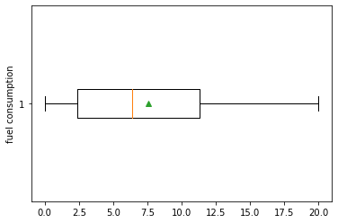

```python
xlabels = ["fuel consumption","acceleration","speed","engine speed","cumulative distance"]

plt.boxplot([df1["CONSUM"]],vert=False,showmeans=True,sym='r*');
plt.ylabel("fuel consumption")
```

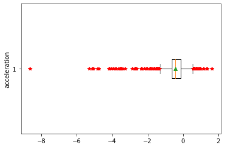

```python
plt.boxplot([df1["LONGACC"]],vert=False,showmeans=True,sym='r*');
plt.ylabel("acceleration")
```

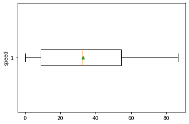

```python
plt.boxplot([df1["SPEED"]],vert=False,showmeans=True,sym='r*');
plt.ylabel("speed")
```

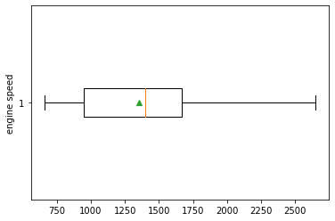

```python
plt.boxplot([df1["WHEEL"]],vert=False,showmeans=True,sym='r*');
plt.ylabel("engine speed")
```

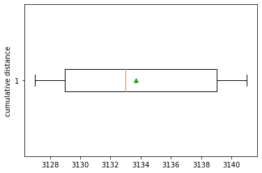

```python
plt.boxplot([df1["CUMDIS"]],vert=False,showmeans=True,sym='r*');
plt.ylabel("cumulative distance")
```

From the boxplot comparison of rushhour, the mean value of the fuel consumption is 7.56. The data of the fuel consumption has no outliers.

From the boxplot comparison of rushhour, the mean value of the acceleration is -0.422438，the variance of the acceleration is large. In addition, there are many outliers in the data and they are widely distributed. Therefore, it shows from the side that the driver often stops and starts quickly while driving, and the drive is not stable enough, and the driving habits may be bad.

From the boxplot comparison of speed, the mean value of the speed is 32.740143. The data of the speed has no outliers.

From the boxplot comparison of engine speed, the mean value of the engine speed is 1354.246667. The data of the engine speed has no outliers.

## Map visualization

```python
from folium import plugins
import folium

# the center of the route
map_1 = folium.Map([40.17939944 , 122.099839], zoom_start=13)

# coordinate of the car
location = df1[["LAT","LONG"]]

print(location)

route = folium.PolyLine(
 location,
 weight=3,
 color='#8600FF',
 opacity=0.8
).add_to(map_1)
map_1
```

```
            LAT        LONG
0     40.202908  122.095112
1     40.202908  122.095112
2     40.202908  122.095112
3     40.202908  122.095112
4     40.202908  122.095112
...         ...         ...
1570  40.172153  122.105687
1571  40.172153  122.105687
1572  40.172153  122.105687
1573  40.172153  122.105687
1574  40.172153  122.105687

[1575 rows x 2 columns]
```

[interactive chart not shown]

After visualizing the map data,we find that the path on the map is not completely overlap with the existing road. This may be because data collectors need to desensitize the GPS data of the vehicle due to user privacy considerations, but the approximate location will not have too much difference.Therefore, we can analyze the driving behavior of the owner from the road conditions and geographic information around the route.

Besides this, we find that the data collection point was near the railway station in Bayuquan District, Yingkou City, Liaoning Province.The area is remote, beside the highway section. We speculate that the owner is driving along Bincheng Avenue to Xiongyuehe Road to Xiongyue Town.We note that Xiongyuehe Road is a branch of National Highway G228.

Therefore, the car is faster, but it should be combined with the geographical background to make a further analysis of the driver’s driving behavior.